# Narzędzia do wizualizacji danych

05-10-2020

## O mnie

Alicja Gosiewska

- Doktorantka (MiNI PW), [MI2 DataLab](https://mi2-warsaw.github.io/),
- Machine Learning Engineer w Tuatara,
- [Warszawskie Spotkania Entuzjastów R (SER)](https://www.meetup.com/Spotkania-Entuzjastow-R-Warsaw-R-Users-Group-Meetup/),
- R-Ladies Warsaw,
- PoweR: warsztaty Python + R.

Kontakt: a.gosiewska@mini.pw.edu.pl

## Cel Przedmiotu

## Cel Przedmiotu I

[figure not shown]

Źródło: https://medium.com/@ODSC/3-things-your-boss-wont-care-about-in-your-data-visualizations-479b8541534a

## Cel Przedmiotu II

[figure not shown]

Źródło: https://infogram.com/blog/do-this-not-that-data-visualization-before-and-after-examples/

## Sprawy organizacyjne

Repozytorium przedmiotu: https://github.com/mini-pw/2021Z-DataVisualizationTechniques <- KLIK

Wykłady:

- “Teoria” i finalne prezentacje projektów,

Laboratoria:

- Praktyka: poznawanie narzędzi, tworzenie poprawnych wizualizacji,
- Prace Domowe

Projekty:

- Konsultacje, prezentacje, zadania i dyskusje.

## Sprawy organizacyjne

**Projekt 1 (16.11.2020)**

- Plakat/ściągawka(cheatsheet)/graf wspomagający wizualizowanie

**Projekt 2 (14.12.2020)**

- Wizualizacja danych dotyczących COVID

**Projekt 3 (18.01.2020)**

- Interaktywna wizualizacja

## Narzędzia

- Programistyczne (R, Python JavaScript),
- Programy graficzne (Inkscape),
- Programy dedykowane do wizualizacji danych (Tableau).

## Podział narzędzi

**Deklaratywne:**

- zadanie: warunki jakie musi spełniać wizualizacja,
- jak wizualizacja jest wykonywana jest rozstrzygane wewnętrznie i niezależnie od użytkownika,
- oddzielenie specyfikacji od wykonania.

**Imperatywne:**

- zadanie: krok po kroku jak stworzyć wizualizację,
- użytkownik w pełni kontroluje każdy detal wizualizacji,
- jeśli warunki jakie musi spełniać wizualizacja zmienią się nawet odrobinę, instrukcja tworzenia może się zmienić znacząco.

## Języki Wizualizacji Danych

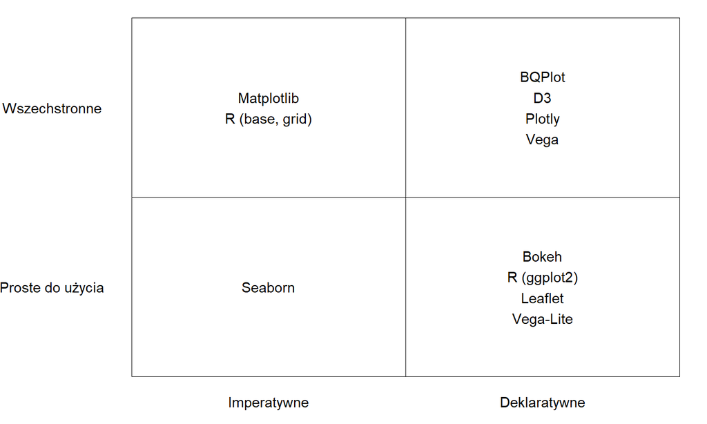

## ggplot (R)

https://ggplot2.tidyverse.org/

[figure not shown]

## matplotlib (Python)

https://matplotlib.org/

Rozszerzenia: https://mpld3.github.io/

[figure not shown]

## seaborn (Python)

Oparte na matplotlib

Świetne szablony wizualizacji! https://seaborn.pydata.org/

[figure not shown]

## plot.ly

Interaktywne wizualizacjie w Javascript z interfejsem w Python i R.

https://plotly.com/python/line-and-scatter/

plotly.js: https://github.com/plotly/plotly.js

plotly.py: https://github.com/plotly/plotly.py

plotly.R: https://github.com/ropensci/plotly

## Inkscape

https://inkscape.org/

Darmowe narzędzie do edycji grafik wektorowych.

[figure not shown]